### Import dataset and library

```r
df <- read.csv("survey.csv",stringsAsFactors=T)
library("tidyverse")
library("gridExtra")
```

### Str & Summary

```r
df %>% dim
```

```
## [1] 164  10
```

```r
# summary
df %>% summary
```

```
##       Age          Gender    self_employed family_history treatment
##  Min.   :18.0   Female: 22   No  :134      No :107        No :94
##  1st Qu.:27.0   Male  :142   Yes : 12      Yes: 57        Yes:70
##  Median :31.0                NA's: 18
##  Mean   :31.1
##  3rd Qu.:35.0
##  Max.   :50.0
##    work_interfere         no_employees remote_work tech_company       benefits
##  Never    :37     01-05         :21    No :107     No : 22      Don't know:56
##  Often    :14     06-25         :42    Yes: 57     Yes:142      No        :49
##  Rarely   :28     100-500       :20                             Yes       :59
##  Sometimes:52     26-100        :50
##  NA's     :33     500-1000      : 8
##                   More than 1000:23
```

```r
df <- df %>% select(treatment, Age, Gender, family_history, no_employees, tech_company)

df %>% str
```

```
## 'data.frame':    164 obs. of  6 variables:
##  $ treatment     : Factor w/ 2 levels "No","Yes": 2 1 1 2 1 1 2 1 2 1 ...
##  $ Age           : int  37 44 32 31 31 33 35 39 42 23 ...
##  $ Gender        : Factor w/ 2 levels "Female","Male": 1 2 2 2 2 2 1 2 1 2 ...
##  $ family_history: Factor w/ 2 levels "No","Yes": 1 1 1 2 1 2 2 1 2 1 ...
##  $ no_employees  : Factor w/ 6 levels "01-05","06-25",..: 2 6 2 4 3 2 1 1 3 4 ...
##  $ tech_company  : Factor w/ 2 levels "No","Yes": 2 1 2 2 2 2 2 2 2 2 ...
```

# Inspect and Transform Individual Variables

### Binary Vairables

For treatment, family_history, no_employees, and tech_company variables, the pattern and type are so clean that they do not need to inspect and transform. Nevertheless, I still need to explain basic information of them one by one.

#### **Treatment**

Whether employees have sought mental health care?

```r
df$treatment %>% table
```

```
## .
##  No Yes
##  94  70
```

#### **Family_History**

Whether employees seeking mental health consultation is affected by family history.

```r
df$family_history %>% table
```

```
## .
##  No Yes
## 107  57
```

#### **Tech_company**

```r
df$tech_company %>% table
```

```
## .
##  No Yes
##  22 142
```

### Categorical Variables

#### **No_employees**

The number of employees in a tech company can help me to answer some questions: Does the size of the company affect the mental health of employees? If the number of employees is large, does it mean that the competition is stronger than small companies and employees are more likely to have mental health problems?

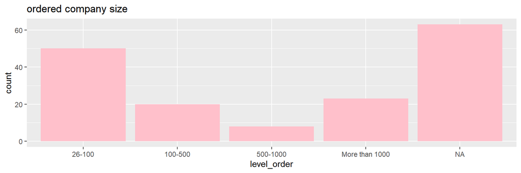

```r
# ordered no_employees level
level_order <- factor(df$no_employees, levels = c("1-25","26-100","100-500", "500-1000","More than 1000"))

# view the company distribution based on company size
df %>% ggplot(aes(x=level_order))+
  geom_bar(fill = "pink") + ggtitle("ordered company size")
```

```r
# view the specific number of company in each size range
df$no_employees %>% table
```

```
## .
##          01-05          06-25        100-500         26-100       500-1000
##             21             42             20             50              8
## More than 1000
##             23
```

#### **Gender**

We want to know whether the majority of employees seeking mental health care are male or female.

```r
# Gender categories barplot
G1 <- df %>% ggplot(aes(x=Gender)) +
  geom_bar() + ggtitle("Categories of Gender")
```

```r
# Create the list of three categories
Male <- c("Male")
Female <- c("Female")
Others <-c ("Others")

# Categorize genders
df$Gender <- sapply(
  as.vector(df$Gender),
  function(x) if(x %in% Male) "Male" else x )

df$Gender <- sapply(
  as.vector(df$Gender),
  function(x) if(x %in% Female) "Female" else x )

df$Gender <- sapply(
  as.vector(df$Gender),
  function(x) if(x %in% Others) "Others" else x )
df$Gender <- as.factor(df$Gender)

# Verify the result
df$Gender %>% table
```

```
## .
## Female   Male
##     22    142
```

```r
# Create the relative frequency table of gender
table(df$Gender)/length(df$Gender)
```

```
##
##    Female      Male
## 0.1341463 0.8658537
```

```r
# Group by Gender and count each group
gender_diversity <- df %>%
  group_by(Gender) %>%
  dplyr::summarize(count = n())
gender_diversity
```

```
## # A tibble: 2 x 2
##   Gender count
##   <fct>  <int>
## 1 Female    22
## 2 Male     142
```

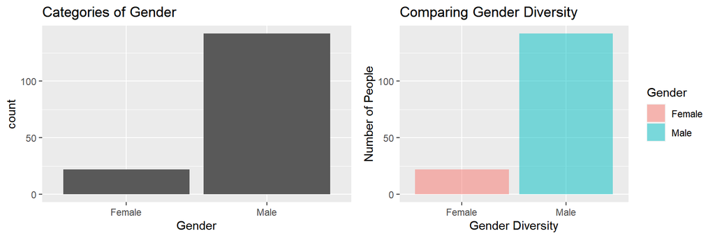

```r
# Visualize the number of subjects in each gender type
G2 <- ggplot(gender_diversity, aes(x = Gender, y = count, fill = Gender)) +
  geom_bar(stat = "identity", alpha = 0.5) +
  xlab("Gender Diversity") +
  ylab("Number of People") +
  ggtitle("Comparing Gender Diversity")

grid.arrange(G1, G2, nrow = 1)
```

After transformed, the variable “`gender`” can be used to do some comparisons, which can help me to answer the goal.

### Continuous Variable

#### **Age**

We are planning to look at the frequency distribution of age groups for seeking mental health care in the tech workplace. Which group has the highest frequency?

```r
#Age distribution
g1 <- df %>% ggplot(aes(x=Age)) +
  geom_histogram() + ggtitle("Distribution of Age")
```

I decided to perform the following transformations to Age variable:

- The variable “`Age`” is continuous, so I used the median to replace negative values and outliers.
- Inspecting distribution of Age
- For the convenience of the following steps, I classified the age groups.
- Inspecting the visualization of the number of employees in each age group.

```r
# Replacing negative values and outliers with median
df$Age[which(df$Age<0)]<- median(df$Age)
df$Age[which(df$Age>100)]<- median(df$Age)
Age1 <- df$Age

# Summary Age
summary(df$Age)
```

```
##    Min. 1st Qu.  Median    Mean 3rd Qu.    Max.
##    18.0    27.0    31.0    31.1    35.0    50.0
```

```r
# Histogram of Age
g2 <- ggplot(df,aes(x=Age))+geom_histogram(aes(y=..density..), fill="pink")+geom_density(col="#3438BD",alpha = 0.5)+labs(x="Age",title="Distribution of Transformed Age")

# Age categorization#
df$Age<-cut(df$Age, breaks = c(0, 16, 34, 60, 75), labels = c('Fresh', 'Junior', 'Senior', 'Super'))

# Verify Age group
df$Age %>% table
```

```
## .
##  Fresh Junior Senior  Super
##      0    119     45      0
```

```r
# Group by Age Group and count each group
age_group <- df %>%
  group_by(Age) %>%
  dplyr::summarize(count = n())
age_group
```

```
## # A tibble: 2 x 2
##   Age    count
##   <fct>  <int>
## 1 Junior   119
## 2 Senior    45
```

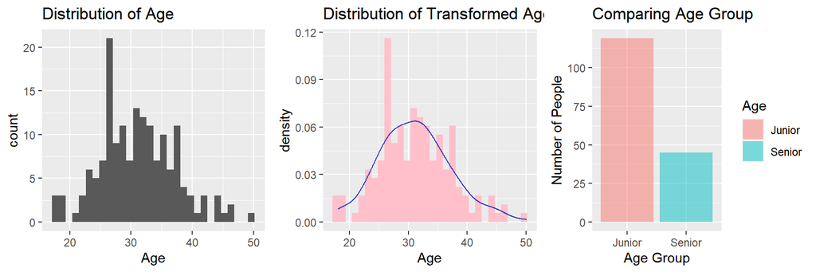

```r
# Visualize the number of subjects in each Age Group
g3 <- ggplot(age_group, aes(x = Age, y = count, fill = Age)) +
  geom_bar(stat = "identity", alpha = 0.5) +
  xlab("Age Group") +
  ylab("Number of People") +
  ggtitle("Comparing Age Group")

grid.arrange(g1, g2, g3, nrow = 1)
```

### Summary

1. - There are no any change on target variable “`treatment`” and predictor “`family_history`”, “`no_employees`”, “`tech_company`”.
2. - Missing values and outliers of variable `Age` were replaced by the median to keep the data integrity.
3. - The predictor `gender` consolidated same gender.

```r
# Update Summary
summary(df)
```

```
##  treatment     Age         Gender    family_history         no_employees
##  No :94    Fresh :  0   Female: 22   No :107        01-05         :21
##  Yes:70    Junior:119   Male  :142   Yes: 57        06-25         :42
##            Senior: 45                               100-500       :20
##            Super :  0                               26-100        :50
##                                                     500-1000      : 8
##                                                     More than 1000:23
##  tech_company
##  No : 22
##  Yes:142
##
##
##
##
```

# Inspection and Transform Multivariate Relationships

In this part, I am planning to focus on the relationship between variables.

### Target ~ Predictor Relationship

#### **Treatment vs Tech-company**

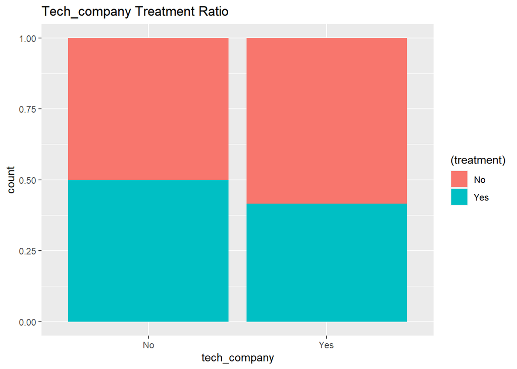

```r
# Comparing tech_company treatment ratio
df %>% ggplot(aes(x=tech_company, fill = (treatment))) +
  geom_bar(position = "fill") + ggtitle("Tech_company Treatment Ratio")
```

```r
# Filter a dataset only focusing on tech_company
Tech <- df %>% select(treatment, Age, Gender, family_history, no_employees, tech_company) %>% filter(tech_company == "Yes")
summary(Tech)
```

```
##  treatment     Age         Gender    family_history         no_employees
##  No :83    Fresh :  0   Female: 19   No :92         01-05         :20
##  Yes:59    Junior:108   Male  :123   Yes:50         06-25         :40
##            Senior: 34                               100-500       :18
##            Super :  0                               26-100        :41
##                                                     500-1000      : 8
##                                                     More than 1000:15
##  tech_company
##  No :  0
##  Yes:142
##
##
##
##
```

Since I pay more attention on tech industry, I filtered a new dataset only including the tech industry. And next, I also make two graphs for each variable to guarantee all data can represent tech industry.

#### **Treatment vs Age**

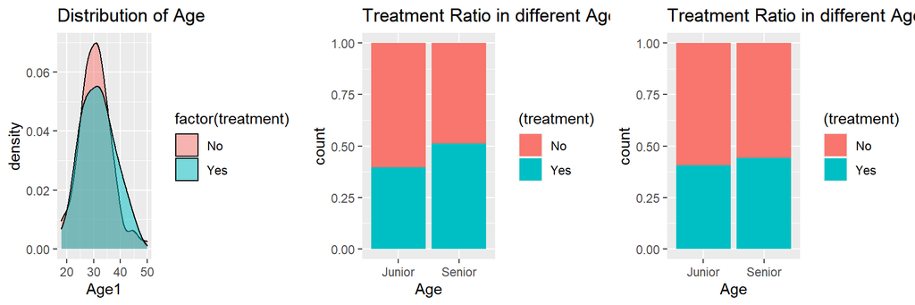

```r
# Density of Age
A1 <- df %>% ggplot(aes(x=Age1, fill = factor(treatment))) +
  geom_density(alpha = 0.5) + ggtitle("Distribution of Age")

# Comparing treatment ratio in Age groups
A2 <- df %>% ggplot(aes(x=Age, fill = (treatment))) +
  geom_bar(position = "fill") + ggtitle("Treatment Ratio in different Age Groups")

# Comparing treatment ratio in Age groups focusing on tech field
A3 <- Tech %>% ggplot(aes(x=Age, fill = (treatment))) +
  geom_bar(position = "fill") + ggtitle("Treatment Ratio in different Age Groups on tech field")


grid.arrange(A1, A2, A3, nrow = 1)
```

The categorical barplot also supports my statement. Additionally, I found that, for the senior age group, the mental health issue of employees is serious because the number of people who accepted mental health treatment is higher than of people with untreated.

#### **Treatment vs Gender**

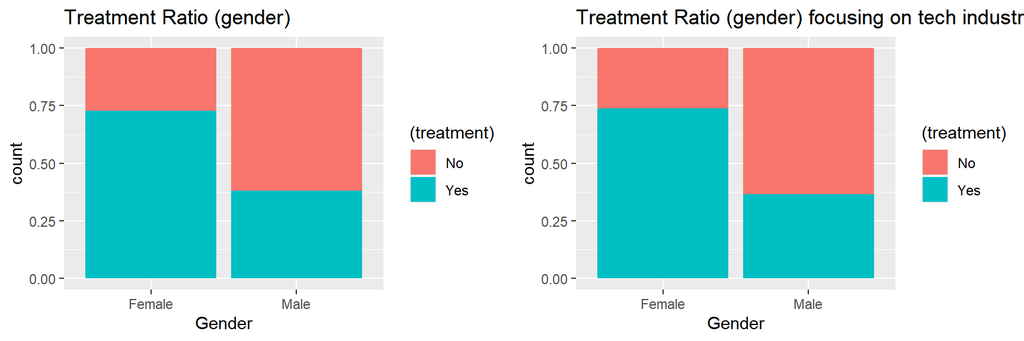

```r
# Comparing treatment ratio in Gender groups
g1 <- df %>% ggplot(aes(x=Gender, fill = (treatment))) +
  geom_bar(position = "fill") + ggtitle("Treatment Ratio (gender)")

# Comparing treatment ratio in Gender groups focusing on tech industry
g2 <- Tech %>% ggplot(aes(x=Gender, fill = (treatment))) +
  geom_bar(position = "fill") + ggtitle("Treatment Ratio (gender) focusing on tech industry")

grid.arrange(g1, g2, nrow =1)
```

It didn’t come as a surprise that the number of males is higher than females in the workplace, especially in the tech field.

Also, it is the fact that men’s ability to resist pressure is higher than women’s. The plot supports this fact. Although the count of the male is higher than female, the number of male employees with treatment is less than male employees without treatment. However, for female, twice as many people have sought mental health care as have not, which illustrates that women’s work and psychological pressure is significantly higher than men’s.

#### **Treatment vs Family_history**

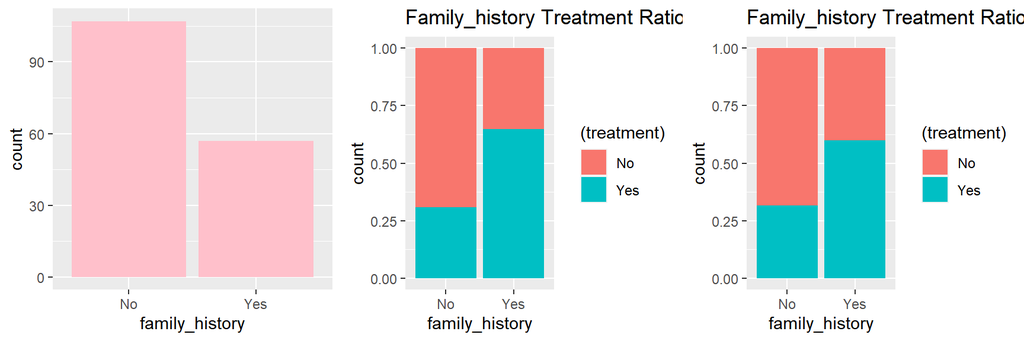

```r
# View Family_history ratio
f1 <- df %>% ggplot(aes(x=family_history)) +
  geom_bar(fill = "pink")

# Comparing Family_history treatment ratio
f2 <- df %>% ggplot(aes(x=family_history, fill = (treatment))) +
  geom_bar(position = "fill") + ggtitle("Family_history Treatment Ratio")

# Comparing Family_history treatment ratio focusing on tech industy
f3 <- Tech %>% ggplot(aes(x=family_history, fill = (treatment))) +
  geom_bar(position = "fill") + ggtitle("Family_history Treatment Ratio (Tech)")

grid.arrange(f1, f2, f3, nrow = 1)
```

The comparison plot shows that employees with family therapy history are significantly higher than those without a family history. This is expected, it is a fact that people with family therapy history pay more attention to mental health problems because if family members have experienced the negative pressure brought by mental health, their other family members are more aware of mental health. Even if there is some pressure they can bear, they may choose to relieve the stress through mental health treatment.

#### **Treatment vs Number of Employees**

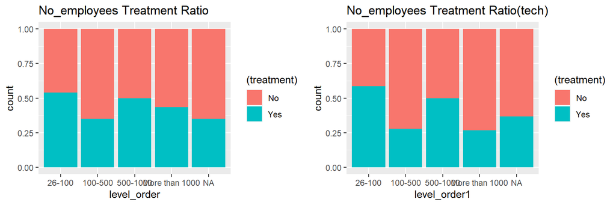

```r
# ordered no_employees level
level_order1 <- factor(Tech$no_employees, levels = c("1-5","6-25","26-100","100-500", "500-1000","More than 1000"))
# Comparing no_employees treatment ratio
n1 <- df %>% ggplot(aes(x=level_order, fill = (treatment))) +
  geom_bar(position = "fill") + ggtitle("No_employees Treatment Ratio")

# # Comparing no_employees treatment ratio focusing on tech industry
n2 <- Tech %>% ggplot(aes(x=level_order1, fill = (treatment))) +
  geom_bar(position = "fill") + ggtitle("No_employees Treatment Ratio(tech)")

grid.arrange(n1, n2, nrow = 1)
```

After consideration, I think the reason why large-scale companies do not increase the number of employees in mental health treatment is that large-scale companies pay more attention to mental health. Companies set up psychological counseling for employees to alleviate the pressure of employees.

### Check for multicollinear predictors

Because there is only one continuous variable, we do not need to check for multicollinear predictors.

### Summary

- From the graphs, we can intuitively see the relationship between each predictor and target:
  - `Age`: The proportion of senior people seeking psychological consultation is the most.
  - `Gender`: Female employees’ mental health in technology industry should be paid more attention.
  - `Family_history`: Employees with family history of mental health are more likely to seek mental health care.
  - `no_employees`: It is impossible to draw a specific conclusion from the scale of the company.
- From my personal point of view, graphs reflected the relationship between predicor and target, but I prefer to build a model to see which variables have a direct impact on mental health treatment.

# Modeling

```r
summary(Tech)
```

```
##  treatment     Age         Gender    family_history         no_employees
##  No :83    Fresh :  0   Female: 19   No :92         01-05         :20
##  Yes:59    Junior:108   Male  :123   Yes:50         06-25         :40
##            Senior: 34                               100-500       :18
##            Super :  0                               26-100        :41
##                                                     500-1000      : 8
##                                                     More than 1000:15
##  tech_company
##  No :  0
##  Yes:142
##
##
##
##
```

For my baseline logistic model, I pay attention to four predictors I selected, which are primary elements relating to the mental health treatment.

```r
# Fit logistic model to full data
lm <- glm(treatment ~ Age + Gender + no_employees + family_history, data = Tech, family = "binomial")
summary(lm)
```

```
##
## Call:
## glm(formula = treatment ~ Age + Gender + no_employees + family_history,
##     family = "binomial", data = Tech)
##
## Deviance Residuals:
##     Min       1Q   Median       3Q      Max
## -1.6668  -0.9877  -0.6010   1.0678   1.9435
##
## Coefficients:
##                            Estimate Std. Error z value Pr(>|z|)
## (Intercept)                 0.25538    0.72703   0.351  0.72540
## AgeSenior                   0.03198    0.45157   0.071  0.94355
## GenderMale                 -1.70134    0.60138  -2.829  0.00467 **
## no_employees06-25           0.35899    0.62934   0.570  0.56839
## no_employees100-500        -0.17397    0.78028  -0.223  0.82356
## no_employees26-100          1.23189    0.62521   1.970  0.04880 *
## no_employees500-1000        0.34178    0.95834   0.357  0.72137
## no_employeesMore than 1000 -0.31050    0.81872  -0.379  0.70450
## family_historyYes           1.15759    0.39600   2.923  0.00346 **
## ---
## Signif. codes:  0 '***' 0.001 '**' 0.01 '*' 0.05 '.' 0.1 ' ' 1
##
## (Dispersion parameter for binomial family taken to be 1)
##
##     Null deviance: 192.78  on 141  degrees of freedom
## Residual deviance: 164.82  on 133  degrees of freedom
## AIC: 182.82
##
## Number of Fisher Scoring iterations: 4
```

# Interpreting coefficients

I plan to see log-odds and odds ratios in action.

First, I will look at the raw logistic regression coefficients from the model, which are the log-odds:

```r
# Raw logistic regression coefficients
lm %>% coefficients %>% round(3)
```

```
##                (Intercept)                  AgeSenior
##                      0.255                      0.032
##                 GenderMale          no_employees06-25
##                     -1.701                      0.359
##        no_employees100-500         no_employees26-100
##                     -0.174                      1.232
##       no_employees500-1000 no_employeesMore than 1000
##                      0.342                     -0.310
##          family_historyYes
##                      1.158
```

Second, I will look at the odds ratios by exponentiating the log-odds:

```r
lm %>% coefficients %>% exp %>% round(3)
```

```
##                (Intercept)                  AgeSenior
##                      1.291                      1.032
##                 GenderMale          no_employees06-25
##                      0.182                      1.432
##        no_employees100-500         no_employees26-100
##                      0.840                      3.428
##       no_employees500-1000 no_employeesMore than 1000
##                      1.407                      0.733
##          family_historyYes
##                      3.182
```

**Here is my interpreation:**

There are two main effects which are gendermale and family_history,reporting by percent decreasing or increasing in the odds of treatment. At the same time, I do not interpret the intercept.

# Evaluating predictive performance

For evaluating predcitive performance, I need to split the dataset into two subsets:one is train dataset, another one is test dataset. I will use train dataset to train the model, and then use test dataset to inspect the accuracy of the model.

### **Train/test split**

I split the dataset with an 80:20 split:

```r
# Randomly select train/test split indices with 80% training size
n <- nrow(Tech)
train_ind <- sample(seq_len(n), size = floor(0.8*n))

# Split training/testing sets
Tech_train <- Tech[train_ind, ]
Tech_test <- Tech[-train_ind, ]

# Define function for feature enginerring pipeline
transformations <- function(Tech) {
   # Gender
   # Create the list of three categories
Male <- c("Male")
Female <- c("Female")
Others <-c ("Others")

# Categorize genders
Tech$Gender <- sapply(
  as.vector(Tech$Gender),
  function(x) if(x %in% Male) "Male" else x )

Tech$Gender <- sapply(
  as.vector(Tech$Gender),
  function(x) if(x %in% Female) "Female" else x )

Tech$Gender <- sapply(
  as.vector(Tech$Gender),
  function(x) if(x %in% Others) "Others" else x )

# Age
# Replacing negative values and outliers with median
Tech$Age <- as.numeric(Tech$Age)
Tech$Age[which(Tech$Age<0)]<- median(Tech$Age)
Tech$Age[which(Tech$Age>100)]<- median(Tech$Age)

# Summary Age
summary(Tech$Age)

# Age categorization#
Tech$Age1 <- cut(Tech$Age, breaks = c(0, 16, 34, 60, 75), labels = c('Fresh', 'Junior', 'Senior', 'Super'))

# Verify Age group
Tech$Age1 %>% table

# Return the transformed dataframe
return(Tech)
}
# Apply feature engineering to each subset
Tech_train <- Tech_train %>% transformations
Tech_test <- Tech_test %>% transformations

# Checking train data
Tech_train %>% head(2)
```

```
##    treatment Age Gender family_history no_employees tech_company  Age1
## 49        No   2   Male             No      100-500          Yes Fresh
## 5         No   2   Male            Yes        06-25          Yes Fresh
```

```r
# checking test data
Tech_test %>% head(2)
```

```
##   treatment Age Gender family_history no_employees tech_company  Age1
## 2        No   2   Male             No        06-25          Yes Fresh
## 4        No   2   Male             No      100-500          Yes Fresh
```

**Notice**: I apply the transformations separately for the training and test sets, so I defined function for feature engineering pipeline.

### Fit and Predict

I will use the training set to re-train the logistical regression model and use the trained models to make predictions on the train and test sets.

```r
# Train model
lm_train <- glm(treatment ~ Age + Gender + family_history + no_employees, data = Tech_train, family = "binomial")

# Predict on training set
Tech_train$predict_probs <- predict(lm_train, Tech_train, type = "response")
Tech_train$predict <- ifelse(Tech_train$predict_probs < 0.5, "No", "Yes")

# Predict on test set
Tech_test$predict_probs <- predict(lm_train, Tech_test, type = "response")
Tech_test$predict <- ifelse(Tech_test$predict_probs < 0.5, "No", "Yes")
```

Above, I have model predictions on the train set(within-sample predictions) and test set(out-of-sample predictions). Next, it’s time to evaluate the predictions.

### Evaluation metrics

There are three main confusion matrices and key metrics which are accuracy, precision, and recall). I will show them one by one:

```r
# Confusion matrix - training data
cm_train <- table(Tech_train$treatment, Tech_train$predict, dnn = c("real", "predict"))
cm_train
```

```
##      predict
## real  No Yes
##   No  54  10
##   Yes 23  26
```

```r
paste('Accuracy:', round(( cm_train['Yes','Yes'] + cm_train['No','No'] ) / sum(cm_train),2))
```

```
## [1] "Accuracy: 0.71"
```

```r
paste('Precision:', round(cm_train['Yes','Yes'] / sum(cm_train['Yes',]),2))
```

```
## [1] "Precision: 0.53"
```

```r
paste('Recall:', round(cm_train['Yes','Yes'] / sum(cm_train[,'Yes']),2))
```

```
## [1] "Recall: 0.72"
```

```r
# Confusion matrix ~ testing data
cm_test <- table(Tech_test$treatment, Tech_test$predict, dnn = c("real", "predict"))
cm_test
```

```
##      predict
## real  No Yes
##   No  15   4
##   Yes  7   3
```

```r
paste('Accuracy:', round(( cm_test['Yes','Yes'] + cm_test['No','No'] ) / sum(cm_test),2))
```

```
## [1] "Accuracy: 0.62"
```

```r
paste('Precision:', round(cm_test['Yes','Yes'] / sum(cm_test['Yes',]),2))
```

```
## [1] "Precision: 0.3"
```

```r
paste('Recall:', round(cm_test['Yes','Yes'] / sum(cm_test[,'Yes']),2))
```

```
## [1] "Recall: 0.43"
```

# Interpretations

Based on model results, gender and family history are important factors in mental health care, which can answer the goal. I will illustrate my personal opinions to interpret the question:

#### **The importance of mental health problems in technology industry**

- In the technology industry, mental health problems caused by high-pressure working conditions have attracted significant attention to the industry. Mental health is often (wrongly) seen as a shameful personal defect, so most people are reluctant to admit that they have something to do with it. There are also many misunderstandings about the word “mental illness”, such as “schizophrenia”. At the same time, due to the incomplete popularization of mental health, many employees who need mental health counseling cannot be understood when communicating with others. Drugs cannot alleviate the resulting pain. Therefore, mental health problems in the working environment should be highly valued, especially in the technology industry. Hence, who needs mental health treatment more is the fundamental factor to solve the mental health problems in the technology industry. That is why I focus on this data.

#### **Gender side**

- In the technology industry, it is an indisputable fact that there are more male employees than female employees. The huge gap between males and females leads to the higher competitive pressure of women than men. At the same time, females have more family responsibilities than males. As a woman, she is not only an employee but also a mother. They should not only take care of the work but also the trivial matters in the family, which will lead to females’ mental pressure higher than males’. Therefore, women need more mental health treatment.
- Males are more rational, and females are more emotional, so females are more sensitive to mental health problems. In other words, females are more concerned about mental health.
- There is more pressure on females’ promotion space in the field of technology. In the process of promotion, there will be differences in communication and thinking modes between males and females. Hence women have more psychological pressure.
- The working environment also affects females’ mental health. First of all, the working environment is a little hard. It is not about the external facilities, but the “rude” oral communication between males of science and technology, or the spread of some taste oriented culture. In many cases, this culture ignores females’ feelings. Therefore, it can be explained that females’ mental health needs to be dredged in such an environment.
- Also, females may feel very lonely in the technology industry because women are scarce in the industry.

#### **Family history**

- First of all, as I stated above, seeking mental health care does not mean having mental health disorders. Many employees seek mental health care to relieve the pressure of work or life. For employees with family history, they may pay more attention to mental health problems and relieve psychological pressure at any time to prevent mental illness.
- Secondly, families with a family history of mental health may have a depressive family atmosphere. The fact is that the workload of the technology industry is relatively large. If the family atmosphere is also depressed, the pressure at work cannot be relieved, so employees are more likely to have mental health problems.

#### **How to solve it?**

- The industry should seriously consider what factors lead to females’ mental health problems and how to solve them. Secondly, for employees with a family history of mental health, the company should pay more attention to psychological counseling. Finally, the technology industry attaches great importance to the mental health of employees. The company needs to establish a specific mental health counseling department and sincerely care about the mental health problems of employees: for example, regular psychological counseling, organizing group building activities and establishing a correct concept of mental health problems. Let every employee talk about mental health as a normal and no longer ashamed of it.

# Summary & Conclusion

In the process of data analysis, I built an analysis framework to get the relationship between predictor and target. Furthermore, around these relationships to think and conclude mental health problems:

- Transforming variables has brought me many gains. The transformation processes of age, gender, and no employees are complex. Age needs to consider outliers, missing values, and histogram distribution. Gender needs to be redefined and grouped. No_employees needs to adjust the order. These codings are the difficulties for me to overcome, but solving these problems made the variables clear and brought me a sense of achievement.
- In the technology industry, gender and family history of mental health are closely related to mental health treatment. + The mental health problems of female employees should be paid more attention.
  - Employees with a family history of mental health should be given a high degree of care and regular psychological treatment.
  - All in all, the company needs to correctly understand the importance of employees’ mental health problems and establish a mental health treatment department.
- If I have more time, I hope to improve the industry’s awareness of employees’ mental health problems. Serious mental health problems not only affect the quality of life, but also reduce work efficiency, and even have more severe consequences. Not only does the company need to establish a mental health system, but I also suggest improving employees’ awareness of mental health treatment and changing the definition of solidified mental health diseases. I hope that employees can think that mental health problems are as common as daily physical examination, so many problems can be improved from the industry, even from society.